# 6. Repeated Measures ANOVA (RMA)

Table of contents

Het verhaal van dit thema

Werkmaterialen — R-pakketten en functies

Notatie — symbolen voor RMA

6.0 Project- en datavoorbereiding

6.1 Het RMA-model fitten en interpreteren

- T1 — Techniek-keuze: RMA, eenwegs-ANOVA, paired t-toets of mixed-effects?
- T2 — Waarom RMA krachtiger dan one-way ANOVA?
- 6.1.a Verkenning — gemiddelden, correlaties en spaghetti
  - Means-tabel — moment-overzicht met `gt`
- T3 — Multivariate vs univariate route, en de sphericity-aanname
- 6.1.b RMA fitten — Leiden’s route via `factorial_design()`
- 6.1.c De vier teststatistics — Pillai als primary
- T4 — Polynomiale contrasten in RMA
- 6.1.d Multivariate effectgrootte

6.2 Contrasten en follow-up

- 6.2.0 Contrasten met de hand opbouwen — rustige bijles-volgorde
- 6.2.a Polynomiale contrasten — eerst hand, dan R
  - In R — met `icontrasts = "contr.poly"`
- T5 — Geplande contrasten en orthogonaliteit
- 6.2.b Paarsgewijze vergelijking met Bonferroni
- T6 — Bonferroni voor RMA-paren handrekenen
- 6.2.c Visualisatie — gemiddeld profiel + spaghetti

6.3 Polynomial-trends-surprise — vier dagdeel-profielen

- De vier profielen
- Visualisatie — vier profielen in één plot
- 6.3.a Reken de drie contrasten uit
- T7 — RMA-aannames
- T8 — Missing data in RMA
- T9 — RMA versus mixed-effects models

6.A Uitbreiding — mixed-design (between $\times$ within)

- T10 — Between $\times$ within: wanneer interactie interessant?

R-spiekblad bij RMA

- Pakketten en data laden — wide en long format
- Verkenning — spaghetti, correlaties, boxplot
- RMA fitten — Leiden’s `factorial_design()` + `Anova()`
- De vier teststatistics — Pillai, Wilks, Hotelling-Lawley, Roy
- Polynomiale contrasten — `contr.poly()`
- Geplande contrasten + Bonferroni voor paren
- Mixed-effects alternatief (kort, voor wie verder wil)
- Visualisatie — spaghetti + gemiddelde lijn

Voorbeeld-tentamenvragen

- Theorie en handreken
- R-practical opdrachtje

Wat blijft liggen

Aan het eind van de dag

Verantwoording

[← Terug naar CountCamp](https://countcamp.org/)·Alle MVDA-thema's

# 6. Repeated Measures ANOVA (RMA)

- Show All Code
- Hide All Code
- View Source

# Het verhaal van dit thema

De kameleon zat op een tak en wisselde nauwelijks merkbaar van kleur.

“Wie mij op één moment vastlegt, mist het voornaamste,” zei hij. “Op een ander moment ben ik weer iemand anders, en allebei ben ik.”

Negentig kameleons, vier momenten van de dag — `ochtend`, `middag`, `avond`, `nacht`. Per kameleon hetzelfde meetinstrument: **mate_van_zichzelf** ($0$-$100$). Niet vier groepen kameleons; **dezelfde** kameleon vier keer. Vraag: verschilt de mate-van-zichzelf systematisch tussen momenten — niet tussen dieren, maar **binnen** elk dier?

De techniek heet **repeated measures ANOVA** RMA.

Bij RMA stel je dezelfde drie vragen als bij ANOVA, maar nu over herhaalde metingen op dezelfde proefpersoon:

1. **Voorspelt het samen iets?** — de **multivariate $F$-toets** (Pillai’s trace en variants) op het binnen-persoon-effect van moment.
2. **Tussen welke momenten zit het verschil?** — polynomiale of geplande contrasten, met **Bonferroni-correctie** voor paarsgewijze vergelijkingen.
3. **Klopt het allemaal wel?** — multivariate normaliteit van de within-subject-vector, geen extreme outliers in trajecten, geen missing data per kameleon.

**NoteA. Wat is RMA?**

**Repeated measures ANOVA** test of metingen **binnen dezelfde persoon** systematisch verschillen tussen condities of momenten. Bij gewone factorial ANOVA zaten in elke groep verschillende dieren; bij RMA zit elke kameleon **zelf in elke conditie** — ze zijn elkaars vergelijkingsbasis.

Voordeel: tussen-personen-variantie wordt uit de fout gehaald. Wat overblijft is *binnen-persoon*-variatie — typisch veel kleiner dan tussen-personen, en daarmee een krachtiger toets bij dezelfde $N$.

**NoteB. Multivariate vs univariate — onze keuze**

RMA kent twee toetsroutes:

- **Univariate**: behandelt de herhaalde metingen als één lange vector, vereist **sphericity** (gelijke varianties van *verschilscores* tussen alle paren). Bij schending: Greenhouse-Geisser- of Huynh-Feldt-correctie.
- **Multivariate**: behandelt de herhaalde metingen als $p$ aparte DV’s (zoals MANOVA), met Pillai/Wilks/Hotelling-Lawley/Roy. **Geen sphericity-aanname** nodig.

|  | **Multivariate** | **Univariate** |
| --- | --- | --- |
| Sphericity nodig? | nee | ja (anders GG/HF-correctie) |
| Power bij kleine $n$ | minder krachtig | krachtiger als sphericity klopt |
| Power bij grotere $n$ | krachtig genoeg | krachtig |
| Aansluiting op MANOVA | direct ($V$, $\Lambda$, $T^2$, $\theta$) | indirect |
| Didactisch | bouwt voort op thema 5 | nieuwe denkstap |

**Wij volgen de cursus**: de **multivariate route** is de hoofdroute. De Heus verantwoordt de keuze in het cursusboek nuchter:

> *Dit is niet omdat de multivariate aanpak superieur is aan de univariate aanpak — beide leiden meestal (maar niet altijd!) tot ongeveer dezelfde resultaten, en allebei hebben ze sterke en zwakke kanten. De multivariate aanpak is hier vooral om praktische redenen gekozen: omdat het op deze manier het snelst en eenvoudigst uit te leggen is, voortbouwend op de eerder behandelde MANOVA.*

> — De Heus, *Exercise Book*, p. 104 (vertaald uit het Engels)

Pillai is de standaard-keuze, conform thema 5.

**Opmerking voor de oude garde** — vroeger zat **sphericity-correctie** (Greenhouse-Geisser, Huynh-Feldt) wél in het curriculum. Met de multivariate route is die correctie niet langer nodig: de multivariate $F$ heeft de aanname helemaal niet. Wie oude collegehandouts leest of software gebruikt die alleen de univariate route biedt, weet nu waarom dat hier ontbreekt.

**NoteC. Kameleon-frame — per moment iemand anders**

Een kameleon laat zich slecht beschrijven door één meting. Op één moment is hij rustig en bedacht, op een ander moment fel en aanwezig — en in beide gevallen is hij zichzelf, maar dan wel een ander stuk van zichzelf. Wie hem op één moment vastlegt, mist de kleur eronder.

RMA pakt deze veelheid serieus: voor elke kameleon meten we **op meerdere momenten**, en kijken niet of *kameleons onderling* verschillen, maar of *de momenten binnen kameleons* verschillen. Niet “wat is een kameleon?”, maar “hoe verandert hij?”

*Eén ding om mee te nemen*: omdat dezelfde kameleon vier keer wordt gemeten, kan de **volgorde** van metingen het resultaat beïnvloeden — het **carry-over-effect**. Een kameleon die net opgeschrikt is in de ochtend zit nog in zijn schrik in de middag. In de praktijk wordt dat ondervangen door de volgorde te **randomiseren** of te **counterbalancen** (bij meerdere experimentele condities elke volgorde even vaak toepassen). Bij vaste tijdmomenten zoals onze ochtend-middag-avond-nacht is randomiseren niet mogelijk; dan analyseer je het in de tijd zoals hij is, en houd je in je interpretatie rekening met dat eerdere metingen latere kunnen kleuren.

**NoteHoe dit hoofdstuk leest**

Dit hoofdstuk volgt dezelfde drie-laagse structuur als thema 1, 2, 3, 4 en 5:

1. **Verhaal-frame** — wat de kameleon doet of denkt.
2. **Algemene vorm** — abstract, statistiek-Latijn met `Y1`, `Y2`, `Y3`, `Y4`, `mijn_data`.
3. **Voor onze dieren** — uitvoerend, met `#` hekjes en concrete namen.

Plus de antwoorden in zacht roze (collapse), vragen in oker, leesregels in groen, alarm in oranje, don’ts in rood. T-vragen vlechten zich tussen de hoofdvragen door om je rekenintuïtie te oefenen.

# Werkmaterialen — R-pakketten en functies

*De kameleon pakt zijn gereedschap*

| Gereedschap | Waar het voor is | Pakket |
| --- | --- | --- |
| `lm(cbind(Y1, Y2, Y3, Y4) ~ 1)` | Multivariaat lineair model — basis voor multivariate RMA | base |
| `car::Anova(lm_obj, idata, idesign, type = 3)` | RMA via multivariate route — Pillai/Wilks/Hotelling/Roy | `car` |
| `summary(res, multivariate = TRUE)` | Multivariate output met alle vier teststatistics | `car` |
| `contr.poly(k)` | Polynomiale contrasten (lineair, kwadratisch, kubisch, …) | base |
| `t.test(y1, y2, paired = TRUE)` | Paarsgewijze vergelijking tussen twee momenten | base |
| `p.adjust(p, method = "bonferroni")` | Multiple-testing-correctie op $p$-waardes | base |
| `reshape()` | Wide ↔︎ long format omzetten voor visualisatie | base |
| `ggplot2::geom_line(aes(group = id))` | Spaghetti-plot van individuele trajecten | `ggplot2` |

**NoteWaarom `lm(cbind(...) ~ 1)` + `Anova()` voor RMA?**

R kent geen aparte `rmanova()`-functie; de gangbare route is dezelfde als bij MANOVA in thema 5: `cbind()` plakt de momenten tot een matrix-uitkomst, en `car::Anova()` met `idata` (de within-subject design-tabel) en `idesign` (de within-subject formule) doet de RMA. Het intercept-only-model `~ 1` zegt: er zijn geen tussen-persoon-voorspellers — alleen het herhaalde-metingen-deel telt. Bij mixed-design (6.A) komt er wel een between-subject factor in de formule.

# Notatie — symbolen voor RMA

**NoteSleutelsymbolen in dit hoofdstuk**

In dit werkboek zie je telkens dezelfde notatie:

- **$n$** — aantal proefpersonen (hier: kameleons). $N$ in absolute zin is hetzelfde, maar bij RMA spreken we vaak over $n$ voor de proefpersonen en $k$ voor het aantal momenten.
- **$k$** — aantal niveaus van de within-subject factor. Voor de kameleon: $k = 4$ (ochtend, middag, avond, nacht).
- **$\boldsymbol{\mu}$** — vector van populatie-gemiddelden over de $k$ momenten: $\boldsymbol{\mu} = (\mu_1, \mu_2, \ldots, \mu_k)^\top$.
- **$\Lambda$** — Wilks’ Lambda binnen de RMA. Klein = sterk effect.
- **$V$** — Pillai’s trace.
- **$T^2$** — Hotelling-Lawley trace.
- **$\theta$** — Roy’s largest root.
- **$F$** — APA-italic, hier als $F$-approximatie van elk van de vier teststatistics.
- **$df_H$** — hypothesis $df$. Voor eenwegs-RMA met $k$ momenten: $df_H = k - 1$.
- **$df_E$** — error $df$ in de $F$-approximatie. Variant per teststatistic.
- **$df_W$** — within-subject totaal $df = n(k - 1)$.
- **$p$** — $p$-waarde van de $F$-approximatie.
- **Polynomiale contrasten** — orthogonale gewichten voor lineaire ($\text{L}$), kwadratische ($\text{Q}$), kubische ($\text{C}$) trends over geordende niveaus.

Voor inferentie spreek je over de populatie-vector $\boldsymbol{\mu}^*$ (asterisk-notatie); voor rapportage over de steekproef-vector $\bar{\boldsymbol{Y}}$. APA-italic geldt voor enkele Latijnse symbolen ($F$, $t$, $p$, $r$, $N$, $df$); multi-letter symbolen rechtop ($\text{RMA}$, $\text{MS}$, $\text{Pillai}$).

**TipVuistregels zijn afspraken, geen wetten**

De drempels in dit werkboek zijn breed gangbare conventies — niet universeel:

- **Aantal proefpersonen**: $n_{\text{kleinste}} \geq 20$ per groep maakt de multivariate $F$ robuust tegen schending van multivariate normaliteit (zoals bij MANOVA in thema 5). Onder $n < k + 5$ wordt de Pillai-toets onbetrouwbaar (te weinig $df_E$). Check je college-sheets of jouw vakgroep deze drempel hanteert.
- **Welke teststatistic**: bij RMA met intercept-only-model zijn Pillai, Wilks en Hotelling-Lawley wiskundig identiek (zelfde $F$-waarde). Roy idem als er één hypothese-dimensie is. Standaard rapporteer je **Pillai** als primary, conform thema 5.
- **Bonferroni voor paren**: bij $k$ momenten zijn er $k(k-1)/2$ paarsgewijze vergelijkingen. Voor $k = 4$: zes paren, $\alpha_{\text{per paar}} = .05/6 \approx .008$. Strenger dan unprotected paired $t$-tests.
- **Polynomiale contrasten**: voor *geordende* niveaus (tijd, dosis) geven `contr.poly` orthogonale lineaire / kwadratische / kubische trends. Voor *ongeordende* niveaus (kleuren, condities) horen ze niet thuis.
- **Effectgrootte multivariaat**: Pillai $V$ zelf is een effectgrootte (analoog aan $\eta^2$); $V \geq .14$ is een groot effect (Cohen-conventie).
- **Sphericity**: in dit werkboek niet als hoofdroute behandeld, maar de univariate-route bestaat. Greenhouse-Geisser- en Huynh-Feldt-correcties horen daar bij — niet bij de multivariate route.

Verschillende vakgroepen, docenten en handboeken kiezen iets andere drempels. Als je voor een tentamen of opdracht werkt, **check altijd in je eigen college-sheets** welke drempels je docent of vakgroep hanteert. Wij volgen hier consistent één set, maar dat is een keuze, geen natuurwet.

**NoteCode in dit hoofdstuk — wat moet je kunnen typen?**

Code is standaard **open** als je hem moet kunnen typen op het R-practical-tentamen: `lm(cbind(Y1, Y2, Y3, Y4) ~ 1)`, `Anova(., idata, idesign, type = 3)`, `summary(., multivariate = TRUE)`, `contr.poly()`, `t.test(., paired = TRUE)`, `p.adjust()`. Code die alleen ter illustratie dient — verkenning, plot-decoratie, spaghetti-plot, gt-tabel — staat **ingeklapt** met een knopje “Toon code”. Klap hem open als je nieuwsgierig bent; voor het tentamen hoef je hem niet te reproduceren.

# 6.0 Project- en datavoorbereiding

*Aantekeningen netjes, paden kloppen*

Open de meegestuurde projectmap (`06_repeated_measures/`) en dubbelklik op `06_repeated_measures.Rproj`. Daarmee staat je werkomgeving klaar: paden kloppen, RStudio kent de juiste werkmap. De data ligt al in `data/`, de helper-functies in `functions/`. Niets te installeren als de pakketten (`car`, `tidyverse`) op je computer staan; anders één keer:

```r
install.packages(c("car", "tidyverse"))
```

1. **Open de hoofd-dataset.**

```r
load("data/kameleon_momenten.RData")
str(kameleon_momenten)
```

```
'data.frame':   90 obs. of  5 variables:
 $ id     : Factor w/ 90 levels "k01","k02","k03",..: 1 2 3 4 5 6 7 8 9 10 ...
 $ ochtend: num  54.1 77.4 70.1 44.8 56.6 61.5 72.8 55.1 45.3 61.4 ...
 $ middag : num  27.5 52.4 29.9 33.4 25.4 37.8 41.9 16.4 15.3 10.3 ...
 $ avond  : num  51.7 78.4 50.8 34.6 41.7 47.2 35.9 34.8 35.5 57.8 ...
 $ nacht  : num  79 84 100 88.3 70.4 85.1 71.3 68.8 51.9 73 ...
```

Per kameleon vijf waarden: een `id` plus de mate-van-zichzelf op vier momenten — `ochtend`, `middag`, `avond`, `nacht` (elk continu, schaal $0$-$100$). De vier momenten vormen samen het binnen-persoon-traject.

**NoteWide format versus long format**

De data staat in **wide format**: één rij per kameleon, vier kolommen voor de momenten. Voor RMA via `lm(cbind(...) ~ 1)` gebruiken we precies dit format — `cbind()` plakt de momenten tot een matrix-uitkomst.

Voor visualisatie (spaghetti-plot, boxplot per moment) is **long format** handiger: één rij per *meting*, met een `moment`-kolom en een `mate`-kolom. We zetten dat één keer om in 6.1.a en bewaren beide naast elkaar.

**Belangrijke conceptuele knoop**: in wide format zien de vier momenten *eruit* als vier kolommen — alsof het vier verschillende DV’s zijn (zoals bij MANOVA in thema 5). **Dat is een illusie.** RMA heeft conceptueel **één DV** (mate-van-zichzelf) die op vier momenten is gemeten. De kolom-vorm is alleen een handige opslag — niet de inhoudelijke structuur. Bij MANOVA had elke leeuw vier *aparte* gevoelens; hier heeft elke kameleon vier *metingen van hetzelfde gevoel*. Die structuur-omkering zorgt dat de procedure en de aannames anders zijn: bij RMA komt **sphericity** erbij, en het multivariate-vs-univariate-pad krijgt een andere betekenis (zie T3 en de Don’t-callout verderop).

# 6.1 Het RMA-model fitten en interpreteren

*Vier momenten op dezelfde dieren — één hypothese*

> *“Vier keer dezelfde meting bij hetzelfde dier,” mompelde de kameleon. “Niet of de ene kameleon meer zichzelf is dan de andere, maar of de momenten binnen mij van elkaar verschillen. Mijn ochtend tegen mijn middag — daar zit de toets.”*

**NoteVoor je gaat rekenen — vijf vragen aan jezelf**

Het stappenplan, opnieuw, met de techniek-keuze als laatste stap.

1. **Wie of wat wordt er gemeten?** *De kameleon heeft $90$ kameleons genoteerd, elk vier keer.*
2. **Wat wordt er gemeten?** *Eén variabele per moment: mate_van_zichzelf. Plus de moment-aanduiding zelf (ochtend/middag/avond/nacht).*
3. **Onafhankelijk of afhankelijk?** *Onderzoeksvraag: voorspelt moment de mate-van-zichzelf? Dan is **mate_van_zichzelf** afhankelijk ($Y$), en **moment** onafhankelijk (within-subject factor, $k = 4$).*
4. **Meetniveau van elke variabele?** *Mate_van_zichzelf interval ($0$-$100$); moment ordinaal (geordend langs de dag) of nominaal (vier categorieën).*
5. **Welke techniek?** Doorloop de beslisboom:

```
flowchart TD
    A[Hetzelfde dier<br/>meerdere keren gemeten?] -->|ja| Z[RMA<br/><i>dit thema</i>]
    A -->|nee| B[Hoeveel afhankelijke<br/>variabelen?]
    B -->|één| C[Y meetniveau?]
    B -->|meerdere<br/>continue| D[MANOVA<br/><i>thema 5</i>]
    C -->|interval| E[X-en meetniveau?]
    C -->|binair| F[Logistic regression<br/><i>thema 4</i>]
    E -->|alleen interval| G[Multiple regression<br/><i>thema 1</i>]
    E -->|alleen nominaal| H[ANOVA<br/><i>thema 2</i>]
    E -->|gemengd| I[ANCOVA<br/><i>thema 3</i>]
    style Z fill:#faf3e2,stroke:#c9a05a,stroke-width:2px
```

[output not shown]

**NoteBens pijltjes-overzicht — alle MVDA-technieken in één tabel**

Dezelfde keuze, anders genoteerd. Lees als **predictor(en) (meetniveau) → DV(s) (meetniveau)**:

| # | Predictor(en) | DV(s) | Techniek |
| --- | --- | --- | --- |
|  | dich \|X\| | \|Y\| int | $t$-toets |
|  | nom 3+lvl \|X\| | \|Y\| int | éénweg ANOVA |
| **1** | int \|X X …\| | \|Y\| int | **MRA** — thema 1 |
| **2** | nom \|X X\| | \|Y\| int | **factorial ANOVA** — thema 2 |
| **3** | nom + int \|X C\| | \|Y\| int | **ANCOVA** — thema 3 |
| **4** | bo(in) \|X\| | \|Y\| bin | **LRA** — thema 4 |
| **5** | nom \|X\| | \|Y₁ Y₂ …\| int | **MANOVA** — thema 5 |
| **6** | within-subject momenten | \|Y₁ Y₂ Y₃ Y₄\| int | **RMA** — thema 6 |
| **7** | indirect via $M$ | $X \to M \to Y$ pad | **Mediation** — thema 7 |

Eén $Y$ (mate_van_zichzelf), meerdere metingen op dezelfde proefpersoon. Het *herhaalde-metingen-design* is wat de techniek bepaalt. Antwoord: **RMA**.

## T1 — Techniek-keuze: RMA, eenwegs-ANOVA, paired t-toets of mixed-effects?

**NoteVraag T1 — Pen-en-papier**

Voor elk vignet: bepaal het design (binnen-persoon, tussen-persoon, of gemengd) en kies dan de techniek.

**a)** *Een wolf meet bij $50$ wolfjes hun jachtsucces in week 1 en week 8 van een training. Vraag: verandert het succes?*

**b)** *Een hert meet bij $80$ herten op vier seizoenen het hormoonniveau (lente, zomer, herfst, winter). Elk hert wordt op alle vier momenten gemeten.*

**c)** *Een onderwijskundige meet bij $60$ studenten de leesmotivatie, met als groep digitaal-onderwijs versus klassikaal-onderwijs (between).*

**d)** *Een gezinspsycholoog meet bij $45$ koppels relatie-tevredenheid op drie momenten ($t_0$, $t_1$, $t_2$) plus per koppel of ze stedelijk of rurale woonomgeving hebben.*

**CautionAntwoord — open na je eigen poging**

**a)** Twee herhaalde metingen op dezelfde wolfjes. $\Rightarrow$ **paired $t$-toets** (twee niveaus is een speciaal geval van RMA — RMA met $k = 2$ is wiskundig equivalent).

**b)** Vier herhaalde metingen op dezelfde herten. $\Rightarrow$ **RMA** ($k = 4$, één within-subject factor seizoen). De multivariate route uit dit thema.

**c)** Twee groepen, één meting per student. $\Rightarrow$ **eenwegs-ANOVA** (thema 2). Geen herhaalde metingen.

**d)** Drie momenten binnen elk koppel (within) plus woonomgeving stedelijk/ruraal (between). $\Rightarrow$ **mixed-design RMA** (between $\times$ within), zie 6.A. Bij geneste of gekruiste random effects: **mixed-effects model** met `lme4::lmer`.

**Vuistregel.** *Hetzelfde dier meerdere keren* = RMA-familie. Twee metingen → paired $t$. Meer dan twee → RMA. Plus een tussen-persoon factor → mixed-design RMA. Random effects op meerdere niveaus → mixed-effects.

## T2 — Waarom RMA krachtiger dan one-way ANOVA?

**NoteVraag T2 — Pen-en-papier**

Een onderzoeker overweegt: hij heeft $90$ kameleons elk vier keer gemeten. Stel hij gooit het design “weg” en behandelt het als een eenwegs-ANOVA met $360$ onafhankelijke observaties (vier groepen van $90$).

**a)** Welke informatie gooit hij weg door dat te doen?

**b)** In de RMA-decompositie wordt **tussen-persoon-variantie** uit het residu gehaald. Wat blijft er over als residu?

**c)** Bij dezelfde groepsgemiddelden: wordt $F$ groter of kleiner als de residu-MS daalt?

**d)** In welke situatie levert RMA *geen* power-winst op boven eenwegs-ANOVA?

**CautionAntwoord — open na je eigen poging**

**a)** De *koppeling* tussen de vier metingen — dat het dezelfde kameleon is op vier momenten. Een kameleon die op ochtend hoog scoort, heeft kans om ook op nacht hoog te scoren (zijn algemene niveau). Door die koppeling te negeren, behandelt hij vier waarnemingen van dezelfde kameleon als vier onafhankelijke. Dat is statistisch incorrect (dependent observations) en weggegooide informatie.

**b)** RMA splitst de totale $SS$ in: tussen-personen ($SS_{BS} = $ koppen die hoog of laag scoren over alle momenten heen), tussen momenten ($SS_{moment}$, het effect dat we willen toetsen), en within-subject residu ($SS_{resW}$, alleen ruis na verwijdering van persoon en moment). Dat residu is veel kleiner dan het ANOVA-residu.

**c)** Groter. $F = MS_{moment} / MS_{resW}$. Als de noemer daalt en de teller gelijk blijft, schiet $F$ omhoog. Vandaar de power-winst.

**d)** Als de tussen-persoon-correlaties $\rho \approx 0$ — dan is er geen koppeling, alle metingen lijken al op onafhankelijke trekkingen. RMA biedt dan geen winst (en kost zelfs $df$). Vuistregel: RMA verdient zijn keuze bij gemiddelde within-subject correlaties $> .3$.

**Inzicht.** RMA is geen “andere” toets — het is dezelfde $F$-logica met een slimme decompositie van het residu. De winst zit in de noemer.

## 6.1.a Verkenning — gemiddelden, correlaties en spaghetti

Voordat de kameleon fit, kijkt hij eerst.

**Algemene vorm.**

```r
# Gemiddelden per moment.
colMeans(mijn_data[, c("Y1", "Y2", "Y3", "Y4")])

# Correlatiematrix tussen momenten — within-subject samenhang.
cor(mijn_data[, c("Y1", "Y2", "Y3", "Y4")])

# Boxplot per moment.
boxplot(mijn_data[, c("Y1", "Y2", "Y3", "Y4")])
```

**Voor onze dieren.**

```r
# Gemiddelden per moment.
round(colMeans(kameleon_momenten[, c("ochtend", "middag", "avond", "nacht")]), 2)
```

```
ochtend  middag   avond   nacht
  60.09   33.24   46.55   73.49
```

```r
# SD's per moment.
round(apply(kameleon_momenten[, c("ochtend", "middag", "avond", "nacht")], 2, sd), 2)
```

```
ochtend  middag   avond   nacht
  15.37   14.02   13.44   15.15
```

```r
# Correlatiematrix tussen de vier momenten.
round(cor(kameleon_momenten[, c("ochtend", "middag", "avond", "nacht")]), 2)
```

```
        ochtend middag avond nacht
ochtend    1.00   0.47  0.50  0.37
middag     0.47   1.00  0.33  0.36
avond      0.50   0.33  1.00  0.40
nacht      0.37   0.36  0.40  1.00
```

**Toon code (boxplot per moment + spaghetti-plot)**

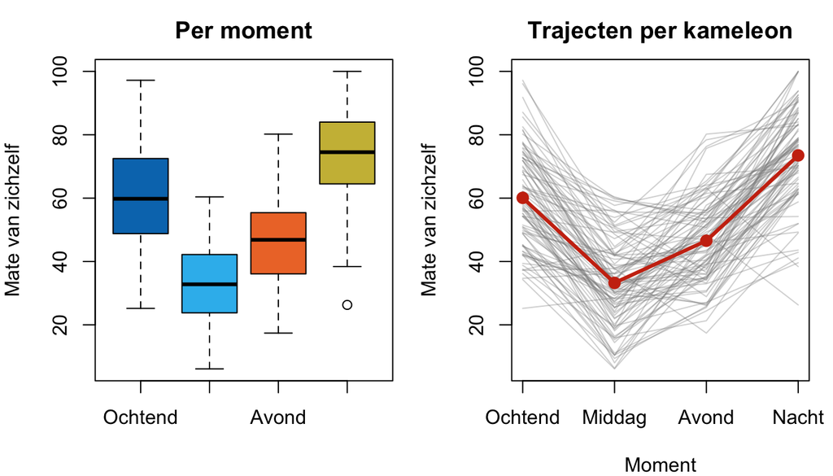

```r
par(mfrow = c(1, 2), mar = c(4, 4, 2.5, 1))

# Boxplot per moment.
boxplot(kameleon_momenten[, c("ochtend", "middag", "avond", "nacht")],
        col  = c("#0077BB", "#33BBEE", "#EE7733", "#CCBB44"),
        ylab = "Mate van zichzelf",
        main = "Per moment",
        names = c("Ochtend", "Middag", "Avond", "Nacht"))

# Spaghetti-plot — individuele trajecten + groepsgemiddelde.
matY <- as.matrix(kameleon_momenten[, c("ochtend", "middag", "avond", "nacht")])
matplot(t(matY), type = "l", lty = 1, col = adjustcolor("#888888", alpha.f = 0.35),
        xaxt = "n", xlab = "Moment", ylab = "Mate van zichzelf",
        main = "Trajecten per kameleon")
axis(1, at = 1:4, labels = c("Ochtend", "Middag", "Avond", "Nacht"))
lines(1:4, colMeans(matY), col = "#CC3311", lwd = 3)
points(1:4, colMeans(matY), col = "#CC3311", pch = 16, cex = 1.4)
```

**Toon code (boxplot per moment + spaghetti-plot)**

```r
par(mfrow = c(1, 1))
```

### Means-tabel — moment-overzicht met `gt`

**Toon code (gt-tabel met means + SD per moment)**

```r
means_v <- colMeans(kameleon_momenten[, c("ochtend", "middag", "avond", "nacht")])
sds_v   <- apply(kameleon_momenten[, c("ochtend", "middag", "avond", "nacht")], 2, sd)

tab_df <- data.frame(
  moment = c("Ochtend", "Middag", "Avond", "Nacht"),
  n      = nrow(kameleon_momenten),
  M      = means_v,
  SD     = sds_v
)

tab_df |>
  gt() |>
  tab_header(title = "Kameleon — mate-van-zichzelf per moment") |>
  fmt_number(columns = c(M, SD), decimals = 2) |>
  cols_label(
    moment = "Moment",
    n      = md("*n*"),
    M      = md("*M*"),
    SD     = md("*SD*")
  ) |>
  tab_options(table.font.size = px(12),
              table.border.top.style    = "none",
              table.border.bottom.style = "none")
```

Kameleon — mate-van-zichzelf per moment

| Moment | *n* | *M* | *SD* |
| --- | --- | --- | --- |
| Ochtend | 90 | 60.09 | 15.37 |
| Middag | 90 | 33.24 | 14.02 |
| Avond | 90 | 46.55 | 13.44 |
| Nacht | 90 | 73.49 | 15.15 |

**NoteVragen 6.1**

**a)** Hoeveel kameleons heeft de kameleon genoteerd? Hoeveel metingen heeft hij in totaal?

**b)** Op welk moment is de mate-van-zichzelf het hoogst? Het laagst?

**c)** Past het patroon bij de verwachting (ochtend redelijk → middag dip → avond herstel → nacht piek)?

**d)** Wat zegt de correlatiematrix over de within-subject samenhang? Zijn de momenten allemaal even sterk gekoppeld?

**e)** Wat zie je in de spaghetti-plot dat je in de boxplots niet ziet?

**CautionAntwoord — open na je eigen poging**

**In gewone woorden.**

1. $n = 90$ kameleons, vier momenten elk = $360$ metingen totaal.
2. De mate-van-zichzelf is het hoogst in de **nacht** ($M \approx 73.49$) en het laagst in de **middag** ($M \approx 33.24$).
3. Het patroon klopt: ochtend redelijk ($M \approx 60$), middag dip ($M \approx 33$), avond herstel ($M \approx 47$), nacht piek ($M \approx 73$) — een opvallende U-vorm met een dip in de middag, en daarbovenop een algemene stijging over de dag.
4. De correlatiematrix laat $r$’s tussen $.33$ en $.50$ zien — alle momenten matig positief gekoppeld, maar geen extreme samenhang. De nacht-correlaties met de overige momenten zijn iets lager dan de ochtend-correlaties, wat suggereert dat het nacht-zelf wat losser staat van de rest van de dag.
5. De spaghetti-plot toont **individuele trajecten**: niet elke kameleon volgt netjes het gemiddelde patroon. Sommigen zijn in de middag bijna tot $0$ gezakt; anderen blijven hoog. De rode lijn is het gemiddelde-traject; daaronder zit de variatie tussen kameleons.

**APA-stijl.**

> Van $n = 90$ kameleons werden vier metingen verzameld op één dag ($N = 360$ metingen). De gemiddelde mate-van-zichzelf was het hoogst in de nacht ($M = 73.49$, $SD = 15.15$) en het laagst in de middag ($M = 33.24$, $SD = 14.02$). Within-subject correlaties tussen de momenten waren matig positief (range $r = .33$-$.50$).

## T3 — Multivariate vs univariate route, en de sphericity-aanname

**NoteVraag T3 — Pen-en-papier**

**a)** Wat houdt **sphericity** precies in voor RMA?

**b)** Waarom is multivariate RMA *niet* afhankelijk van sphericity?

**c)** In welke situatie kan de univariate route krachtiger zijn dan de multivariate?

**d)** Wat doet de Greenhouse-Geisser-correctie als sphericity geschonden is?

**CautionAntwoord — open na je eigen poging**

**a)** Sphericity = de varianties van alle paarsgewijze **verschilscores** tussen momenten zijn gelijk. Bij $k = 4$ momenten zijn er $\binom{4}{2} = 6$ verschilparen; sphericity zegt dat $\text{Var}(Y_i - Y_j)$ voor alle $i, j$ ongeveer hetzelfde is. Dit is een sterkere aanname dan “gelijke varianties per moment”. Mauchly’s $W$-toets test dit, met $H_0$: sphericity geldt.

**b)** Multivariate RMA behandelt de momenten als $k$ aparte DV’s (zoals MANOVA): de toets gebruikt de volledige covariantie-matrix tussen momenten in plaats van te aannemen dat verschilscore-varianties gelijk zijn. Geen aanname over de structuur van die matrix dus geen sphericity-eis.

**c)** Bij **klein $n$** ($n < k + 5$): de multivariate route heeft te weinig $df_E$ en wordt onbetrouwbaar. Univariate route met GG- of HF-correctie behoudt dan power. Bij grotere $n$ wint multivariate vaak.

**d)** Greenhouse-Geisser past de $df$ van de univariate $F$-toets aan: $df_H \cdot \hat\epsilon$ en $df_E \cdot \hat\epsilon$, waar $\hat\epsilon$ tussen $1/(k-1)$ en $1$ ligt. Bij sterke sphericity-schending is $\hat\epsilon$ klein en worden $df$’s kleiner — strengere $F$-drempel, behoud van type-I-fout. Huynh-Feldt is een ietsje minder conservatieve variant van dezelfde correctie.

**Inzicht.** In dit werkboek volgen we de **multivariate route** als hoofdkeuze: bij $n = 90$ ruim genoeg, en geen sphericity-discussie nodig. Voor wie de univariate route wil: zie *Wat blijft liggen* en je eigen college-aantekeningen.

**TipMauchly’s $W$, Greenhouse-Geisser, Huynh-Feldt — wat lees je in de output?**

In de RMA-output van Leiden’s `Anova()` zie je vier dingen die met sphericity te maken hebben:

1. **Mauchly’s $W$** — toets op sphericity ($H_0$: sphericity geldt). Significant $\rightarrow$ sphericity geschonden.
2. **Greenhouse-Geisser (GG) $\hat\epsilon$** — correctie-factor tussen $1/(k-1)$ en $1$. Hoe verder van $1$, hoe sterker de schending.
3. **Huynh-Feldt (HF) $\hat\epsilon$** — iets minder strenge variant van GG.
4. **Bijbehorende GG- en HF-$p$-waardes** — de univariate $F$-toets met aangepaste $df$.

Vuistregel voor het lezen: kijk eerst naar Mauchly. Bij $p > .05$ kun je in principe sphericity aannemen en de unaangepaste univariate $F$ lezen. Bij $p < .05$ rapporteer je liever de GG- of HF-correctie. In ons werkboek volgen we de **multivariate route** als hoofdkeuze (geen sphericity-aanname nodig), maar je moet de Mauchly-/GG-/HF-output **wel kunnen lezen** in de Leiden-uitvoer.

## 6.1.b RMA fitten — Leiden’s route via `factorial_design()`

Leiden’s R-practical schrijft een wrapper voor: `factorial_design()` uit `rstatix`. Die definieert het RMA-design (welke variabelen, welke factor is within, welke is between), en geeft je een object dat je in `Anova()` van `car` stopt voor de feitelijke toets.

**Algemene vorm (long-format data).**

```r
# Stap 0: data in long format brengen — één rij per persoon × moment.
library(tidyr)
long_data <- mijn_wide_data |>
  pivot_longer(cols      = c(Y1, Y2, Y3, Y4),
               names_to  = "moment",
               values_to = "score")

# Stap 1: factorial_design() — vertelt rstatix wat WS-factor is.
library(rstatix)
fd <- factorial_design(
  data   = long_data,
  dv     = score,
  wid    = id,        # persoons-identificatie (within-subject id)
  within = moment     # WS-factor
)

# Stap 2: Anova() op het lm-object dat factorial_design() teruggeeft.
# icontrasts schrijf je hier voor, NIET via options(contrasts=...).
library(car)
res_rma <- Anova(
  fd$model,
  idata      = fd$idata,
  idesign    = fd$idesign,
  icontrasts = c("contr.sum", "contr.poly"),
  type       = "III"
)

# Stap 3: samenvatting — multivariate + univariate samen.
summary(res_rma, multivariate = TRUE)
```

`factorial_design()` doet de wide↔︎long-omzetting onder de motorkap, bouwt de juiste `idata` en `idesign`, en retourneert een lijst met `$model`, `$idata`, `$idesign`. Je geeft die door aan `Anova()` met `icontrasts` als argument — niet via `options(contrasts=)`. Conform Leiden’s R-practical hoofdstuk 6.

**Voor onze dieren.**

```r
library(tidyr)
library(rstatix)
library(car)

# Stap 0: kameleon_momenten staat in wide format — eerst long maken.
kameleon_long <- kameleon_momenten |>
  pivot_longer(
    cols      = c(ochtend, middag, avond, nacht),
    names_to  = "moment",
    values_to = "mate_van_zichzelf"
  ) |>
  mutate(moment = factor(moment,
                         levels = c("ochtend", "middag", "avond", "nacht")))

# Stap 1: factorial_design — kameleon als wid, moment als within-factor.
fd_kam <- factorial_design(
  data   = kameleon_long,
  dv     = mate_van_zichzelf,
  wid    = id,
  within = moment
)

# Stap 2: Anova met icontrasts en type "III".
res_kam <- Anova(
  fd_kam$model,
  idata      = fd_kam$idata,
  idesign    = fd_kam$idesign,
  icontrasts = c("contr.sum", "contr.poly"),
  type       = "III"
)

# Stap 3: samenvatting — multivariate en univariate gelijk weergegeven.
summary(res_kam, multivariate = TRUE)
```

```
Type III Repeated Measures MANOVA Tests:

------------------------------------------

Term: (Intercept)

 Response transformation matrix:
        (Intercept)
avond             1
middag            1
nacht             1
ochtend           1

Sum of squares and products for the hypothesis:
            (Intercept)
(Intercept)     4097579

Multivariate Tests: (Intercept)
                 Df test stat approx F num Df den Df     Pr(>F)
Pillai            1  0.961061 2196.619      1     89 < 2.22e-16 ***
Wilks             1  0.038939 2196.619      1     89 < 2.22e-16 ***
Hotelling-Lawley  1 24.681113 2196.619      1     89 < 2.22e-16 ***
Roy               1 24.681113 2196.619      1     89 < 2.22e-16 ***
---
Signif. codes:  0 '***' 0.001 '**' 0.01 '*' 0.05 '.' 0.1 ' ' 1

------------------------------------------

Term: moment

 Response transformation matrix:
        moment1 moment2 moment3
avond         1       0       0
middag        0       1       0
nacht         0       0       1
ochtend      -1      -1      -1

Sum of squares and products for the hypothesis:
          moment1   moment2   moment3
moment1  16494.43  32709.98 -16319.79
```

[output cut: 22 more lines]

```

       Test statistic p-value
moment        0.95598 0.55674


Greenhouse-Geisser and Huynh-Feldt Corrections
 for Departure from Sphericity

        GG eps Pr(>F[GG])
moment 0.97178  < 2.2e-16 ***
---
Signif. codes:  0 '***' 0.001 '**' 0.01 '*' 0.05 '.' 0.1 ' ' 1

         HF eps   Pr(>F[HF])
moment 1.008238 5.813392e-71
```

**TipKlassieke `car`-route — alternatief**

Voor wie geen `rstatix::factorial_design()` wil gebruiken: dezelfde toets kan via een direct `lm(cbind(...) ~ 1)`-object plus `Anova()` met losse `idata`/`idesign`:

```r
options(contrasts = c("contr.sum", "contr.poly"))
lm_kam <- lm(cbind(ochtend, middag, avond, nacht) ~ 1, data = kameleon_momenten)
idata  <- data.frame(moment = factor(c("ochtend","middag","avond","nacht"),
                                     levels = c("ochtend","middag","avond","nacht")))
res    <- Anova(lm_kam, idata = idata, idesign = ~moment, type = 3)
summary(res, multivariate = TRUE)
```

Wiskundig gelijk; alleen is dit niet wat Leiden’s R-practical voorschrijft. Voor het tentamen ken je de `factorial_design()`-route.

**TipVrijheidsgraden bij RMA — hoofdrekenbaar voorbeeld**

Voor de eenwegs-RMA met factor `moment` ($k = 4$) en $n = 90$ kameleons:

[output not shown]

**Hoofdreken-controle**. Bij $n = 90$, $k = 4$: univariate $F(3, 267) = 215.30$ (verschijnt in het stuk over alternatieve route); multivariate $F(3, 87)$ in de Pillai-output.

Bij $n = 20$, $k = 3$ (kleiner voorbeeld): $df_{cond} = 2$, $df_{resW} = 38$, multivariate $F(2, 18)$.

## 6.1.c De vier teststatistics — Pillai als primary

**NoteVragen 6.1**

**f)** Voor de term `moment`: welke vier teststatistics rapporteert de output? Welke waardes hebben ze?

**g)** Welke $df$ en $p$-waardes horen erbij? Wijzen ze allemaal in dezelfde richting?

**h)** Welke teststatistic rapporteer je als *primary*? Waarom?

**i)** Waarom zijn Pillai, Wilks en Hotelling-Lawley voor de term `moment` allemaal hetzelfde $F$-getal (en Roy ook)?

**CautionAntwoord — open na je eigen poging**

**In gewone woorden.**

6. Voor `moment`: Pillai’s $V = 0.88$, Wilks’ $\Lambda = 0.12$, Hotelling-Lawley $T^2 = 7.61$, Roy’s $\theta = 7.61$.
7. $df_H = 3$, $df_E = 87$ in de $F$-approximatie; alle vier $F = 220.77$, $p < .001$ — allemaal hetzelfde antwoord.
8. Standaard rapporteer je **Pillai’s trace** als primary: het is robuust tegen lichte schendingen van multivariate normaliteit en covariantie-matrix-gelijkheid.
9. De vier teststatistics geven hetzelfde $F$-getal omdat dit een intercept-only-RMA is — er is maar één hypothese-dimensie (de within-subject factor `moment`); alle vier reduceren tot dezelfde wiskundige formulering. Bij mixed-design (between $\times$ within) of bij MANOVA met meerdere factoren lopen ze wél uiteen, zoals in thema 5.

**APA-stijl.**

> Een eenwegs-RMA met de multivariate route toonde een sterk effect van moment op de mate-van-zichzelf: Pillai’s $V = .88$, $F(3, 87) = 220.77$, $p < .001$. De andere drie teststatistics gaven hetzelfde $F$-getal (Wilks’ $\Lambda = .12$, Hotelling-Lawley $T^2 = 7.61$, Roy’s $\theta = 7.61$), zoals te verwachten bij een intercept-only-RMA.

## T4 — Polynomiale contrasten in RMA

**NoteVraag T4 — Pen-en-papier**

Bij geordende within-subject niveaus (tijd, dosis, moment) kun je in plaats van paarsgewijze vergelijkingen ook **polynomiale contrasten** toetsen.

**a)** Wat toetst een **lineair** contrast bij vier momenten?

**b)** Wat toetst een **kwadratisch** contrast?

**c)** Wat toetst een **kubisch** contrast?

**d)** Polynomiale contrasten zijn **orthogonaal**: wat betekent dat hier?

**e)** Bij vier momenten zijn er drie contrasten ($k - 1$). Waarom precies drie?

**CautionAntwoord — open na je eigen poging**

**a)** Lineair contrast (gewichten $-3, -1, 1, 3$ voor vier geordende niveaus): test of de mate-van-zichzelf een **monotone stijging of daling** over de momenten vertoont. Significant lineair = de mate-van-zichzelf neemt systematisch toe (of af) over de dag.

**b)** Kwadratisch contrast (gewichten $1, -1, -1, 1$): test of de mate-van-zichzelf een **U-vorm of omgekeerde U-vorm** over de momenten heeft — dip in het midden of piek in het midden. Significant kwadratisch bij onze kameleon = “mate-van-zichzelf dipt in middag, hoog aan de uiteinden” (of andersom).

**c)** Kubisch contrast (gewichten $-1, 3, -3, 1$): test of de mate-van-zichzelf een **op-neer-op** of **neer-op-neer**-patroon over de momenten heeft — een S-vormige beweging. Vaak kleinste van de drie als de hoofdpatronen in de mate-van-zichzelf al in lineair en kwadratisch zitten.

**d)** Orthogonaal = de contrasten meten **onafhankelijke** stukken van het patroon. Het lineaire contrast deelt geen variantie met het kwadratische; samen tellen ze alle variatie tussen momenten op tot $SS_{cond}$. Voordelen: elke trend-toets is interpretabel los van de andere.

**e)** Bij $k$ niveaus zijn er $k - 1$ orthogonale contrasten — analoog aan $df_{cond} = k - 1$. Vier momenten geven drie onafhankelijke vragen: lineair, kwadratisch, kubisch. Alles wat *daarna* nog komt zou afhankelijk zijn van eerdere contrasten.

**Inzicht.** Polynomiale contrasten zijn de voorkeur bij **geordende** niveaus; bij **ongeordende** condities (bv. drie ongelijksoortige interventies) horen ze niet thuis — kies dan paarsgewijze of geplande contrasten.

## 6.1.d Multivariate effectgrootte

**NotePillai als effectgrootte voor RMA**

Pillai’s $V$ tussen $0$ en $\min(k - 1, df_H)$ is zelf al een effectgrootte: het analoog van $\eta^2$ in de univariate ANOVA. Cohens vuistregels:

- klein: $V \approx .01$
- matig: $V \approx .06$
- groot: $V \geq .14$

Voor onze kameleon: $V = .88$, ver boven de grote-effect-grens — een zeer sterk binnen-persoon-effect.

Een alternatief is de **partial $\eta^2$ van het univariate equivalent**: $\eta^2_p = SS_{cond} / (SS_{cond} + SS_{resW})$. Voor onze data: $\eta^2_p = 81118 / (81118 + 33532) = .708$.

```r
# Univariate equivalent voor effectgrootte-vergelijking.
# Long format omzetting voor de univariate aov-route.
long_kam <- reshape(
  kameleon_momenten,
  varying   = list(c("ochtend", "middag", "avond", "nacht")),
  v.names   = "mate",
  timevar   = "moment",
  times     = c("ochtend", "middag", "avond", "nacht"),
  direction = "long"
)
long_kam$moment <- factor(long_kam$moment,
                          levels = c("ochtend", "middag", "avond", "nacht"))

# Univariate RMA via aov() — geeft SS_cond en SS_resW direct af.
fit_uni <- aov(mate ~ moment + Error(id/moment), data = long_kam)
summary(fit_uni)
```

```
Error: id
          Df Sum Sq Mean Sq F value Pr(>F)
Residuals 89  41505   466.4

Error: id:moment
           Df Sum Sq Mean Sq F value Pr(>F)
moment      3  81118   27039   215.3 <2e-16 ***
Residuals 267  33532     126
---
Signif. codes:  0 '***' 0.001 '**' 0.01 '*' 0.05 '.' 0.1 ' ' 1
```

```r
# Partial eta^2 = SS_moment / (SS_moment + SS_residu_within)
ss_moment <- 81118
ss_resW   <- 33532
eta2_p    <- ss_moment / (ss_moment + ss_resW)
round(eta2_p, 3)
```

```
[1] 0.708
```

**NoteVraag 6.1**

**j)** Wat is de univariate $F$-waarde voor `moment`? Met welke $df$?

**k)** Welk percentage van de within-subject variantie wordt verklaard door `moment` (partial $\eta^2$)?

**l)** Hoe verhoudt $V = .88$ zich tot $\eta^2_p = .71$? Beide zeer groot — waarom verschillen ze?

**CautionAntwoord — open na je eigen poging**

**In gewone woorden.**

10. Univariaat: $F(3, 267) = 215.30$, $p < .001$ — sterk significant en met grote $df_E$ door alle binnen-persoon-residuen samen.
11. Partial $\eta^2 = .708$ — moment verklaart ongeveer $71\%$ van de within-subject-variantie, zeer groot effect.
12. $V = .88$ en $\eta^2_p = .71$ zijn niet gelijk omdat ze andere maten zijn: $V$ telt eigenvalues van de hypothese-matrix, $\eta^2_p$ is een SS-ratio. Ze convergeren in dezelfde richting (groot effect) maar volgen verschillende schalen. Beide rapporteer je gerust naast elkaar.

**APA-stijl.**

> De multivariate effectgrootte was zeer groot, Pillai’s $V = .88$. De univariate-equivalent partial $\eta^2 = .71$ bevestigt dit beeld.

# 6.2 Contrasten en follow-up

*“Welke momenten zijn de echte motoren?”*

> *“Ik weet nu dat de momenten verschillen,” zei de kameleon. “Maar in welke vorm? Stijgt het over de dag, of dipt het in de middag, of springt het op-en-neer? En welke specifieke paren zijn de drijvende krachten?”*

De multivariate $F$ zegt alleen *dát* moment ertoe doet. Voor *welke trends* en *welke paren* zit het effect, heb je follow-up nodig:

1. **Polynomiale contrasten** — lineair / kwadratisch / kubisch via `contr.poly`.
2. **Geplande contrasten** — theoretisch gemotiveerde vergelijkingen (bv. nacht versus ochtend, middag versus rest).
3. **Paarsgewijze paired $t$-toetsen** met **Bonferroni-correctie** voor alle $k(k-1)/2$ paren.

**TipWat is een contrast eigenlijk?**

Een **contrast** is gewoon een *ingewikkeld verschil van meer dan twee dingen* — met een eentje hier, een halfje daar, een minnetje verderop. Bij **twee** gemiddelden is een contrast simpel: $\mu_1 - \mu_2$, met gewichten $(+1, -1)$. Voor het toetsen heet dat een gepaarde $t$-toets of een ongepaarde, afhankelijk van design.

Bij **drie of meer** gemiddelden kun je oneindig veel contrasten verzinnen — sommige zijn theoretisch zinnig (bv. *“is de eerste meting anders dan het gemiddelde van de andere drie?”*), andere zijn willekeurig. Een **gewogen optelling** $L = c_1\mu_1 + c_2\mu_2 + c_3\mu_3 + c_4\mu_4$ heet een **contrast** zodra de gewichten optellen tot $0$: $\sum_j c_j = 0$. Dan meet het een *verschil* tussen groepen, niet een gemiddelde van groepen.

Voorbeelden: - $\mu_1 - \mu_2$: gewichten $(+1, -1, 0, 0)$ — paarsgewijs, som = 0 ✓ - $\mu_1 - \tfrac{1}{3}(\mu_2 + \mu_3 + \mu_4)$: gewichten $(1, -\tfrac{1}{3}, -\tfrac{1}{3}, -\tfrac{1}{3})$ — eerste vs de rest, som = 0 ✓ - $\mu_1 + \mu_2$: gewichten $(+1, +1, 0, 0)$ — som = 2, **geen contrast** (dit is een gemiddelde van twee)

In RMA-context heten contrasten ook wel **geplande vergelijkingen** als ze theoretisch gemotiveerd zijn. *Polynomiale contrasten* (lineair / kwadratisch / kubisch) zijn een speciale familie geordende contrasten — zie 6.2.a. De *cross-link naar callout C* van thema 5 (“Sjonge sjonge — al die woorden voor één ding”): een **contrast** is hetzelfde gereedschap als een **gewogen optelling**, een **discriminant-functie**, een **lineaire combinatie**. Alleen met de extra eis dat de gewichten optellen tot $0$.

## 6.2.0 Contrasten met de hand opbouwen — rustige bijles-volgorde

Voordat we polynomiale contrasten op de data loslaten via R, bouwen we de **contrast-gewichten zelf op**. Net zoals in de bijles bij Leiden’s drug-experiment, waar Jeanne stap voor stap de vier contrast-gewichten formuleerde voordat ze er statistiek op zette.

**Stappenplan voor een geplande set contrasten:**

1. **Formuleer de onderzoeksvraag** in normale taal. Bv: *“Verschilt de ochtend van de drie latere momenten samen?”*
2. **Vertaal de vraag naar een vergelijking** tussen groepen of groepen-van-groepen. Bv: *ochtend* versus *gemiddelde van middag/avond/nacht*.
3. **Geef gewichten** zodanig dat:
   - de vergeleken kanten optellen tot $0$ (één kant +, één kant −),
   - de absolute som van de positieve gewichten gelijk is aan de absolute som van de negatieve gewichten.
4. **Check**: $\sum_j c_j = 0$. Als de som $\neq 0$: geen contrast, geen vergelijking.
5. **Herhaal** voor elke volgende vraag. Bij $k$ niveaus kun je maximaal $k-1$ **orthogonale** contrasten neerzetten — drie vragen voor vier momenten.

**TipVoorbeeld — drie geplande contrasten op vier momenten**

Stel je vraagt drie dingen, in volgorde:

| Vraag | In gewone taal | Gewichten ochtend / middag / avond / nacht |
| --- | --- | --- |
| **L₁** | *Ochtend vs. de rest* — wijkt de ochtend af van het gemiddelde van middag, avond en nacht? | $(+3, -1, -1, -1)$ |
| **L₂** | *Middag vs. avond+nacht* — binnen de niet-ochtend-momenten: middag vs gemiddeld-laat? | $(0, +2, -1, -1)$ |
| **L₃** | *Avond vs. nacht* — binnen de twee laat-op-de-dag-momenten? | $(0, 0, +1, -1)$ |

**Som van elk contrast** (controle):

- $L_1$: $3 + (-1) + (-1) + (-1) = 0$ ✓
- $L_2$: $0 + 2 + (-1) + (-1) = 0$ ✓
- $L_3$: $0 + 0 + 1 + (-1) = 0$ ✓

**Orthogonaliteit** — inproduct van elk paar gewichten moet $0$ zijn:

- $L_1 \cdot L_2$: $3 \cdot 0 + (-1) \cdot 2 + (-1) \cdot (-1) + (-1) \cdot (-1) = 0 - 2 + 1 + 1 = 0$ ✓
- $L_1 \cdot L_3$: $3 \cdot 0 + (-1) \cdot 0 + (-1) \cdot 1 + (-1) \cdot (-1) = 0 + 0 - 1 + 1 = 0$ ✓
- $L_2 \cdot L_3$: $0 \cdot 0 + 2 \cdot 0 + (-1) \cdot 1 + (-1) \cdot (-1) = 0 + 0 - 1 + 1 = 0$ ✓

Alle drie paren = $0$ → **de set is orthogonaal**. Drie onafhankelijke vragen, elk een eigen stukje van de tussen-momenten-variantie.

**NoteHoe je een contrast-waarde berekent uit groeps-gemiddelden**

Voor elk contrast: vermenigvuldig elk gewicht met het bijbehorende groeps-gemiddelde en tel op:

$$L = c_1 \bar{Y}_1 + c_2 \bar{Y}_2 + c_3 \bar{Y}_3 + c_4 \bar{Y}_4$$

Stel onze kameleon-gemiddelden zijn (verzonnen voor uitleg): $\bar{Y}_{\text{ochtend}} = 60$, $\bar{Y}_{\text{middag}} = 30$, $\bar{Y}_{\text{avond}} = 50$, $\bar{Y}_{\text{nacht}} = 80$.

Dan:

- $L_1 = 3 \cdot 60 + (-1) \cdot 30 + (-1) \cdot 50 + (-1) \cdot 80 = 180 - 30 - 50 - 80 = 20$. Positief — de ochtend zit gemiddeld boven de drie latere momenten samen (al is dat 20 punten op een schaal die loopt van — kijk in je data).
- $L_2 = 0 \cdot 60 + 2 \cdot 30 + (-1) \cdot 50 + (-1) \cdot 80 = 60 - 50 - 80 = -70$. Sterk negatief — middag scoort gemiddeld véél lager dan avond+nacht.
- $L_3 = 0 \cdot 60 + 0 \cdot 30 + 1 \cdot 50 + (-1) \cdot 80 = -30$. Negatief — avond zit onder nacht.

**Interpretatie**: $|L_2| = 70$ is veruit het grootst, dus de *middag-versus-laat*-tegenstelling is het dominantste patroon. *Ochtend-versus-rest* en *avond-versus-nacht* zijn ook present maar zwakker. Welke significant is hangt af van $SE_L$ en de bijbehorende $t$-toets — dat doet R voor je in 6.2.a.

Bij paarsgewijze vergelijkingen ($\mu_1 - \mu_2$ etc.) doe je in feite hetzelfde, maar met gewichten $(+1, -1, 0, \ldots, 0)$. Een paarsgewijze vergelijking is gewoon een speciaal-geval-contrast.

## 6.2.a Polynomiale contrasten — eerst hand, dan R

**TipPolynomiale contrasten zijn een speciale familie**

Bij **geordende** niveaus (tijd, dosis, leeftijd) kun je drie soorten patronen apart toetsen via een vaste set contrast-gewichten:

| Trend | Wat het meet | Gewichten ochtend / middag / avond / nacht |
| --- | --- | --- |
| Lineair $L$ | monotone stijging of daling | $(-3, -1, +1, +3)$ |
| Kwadratisch $Q$ | U- of omgekeerde-U-vorm (piek in het midden) | $(+1, -1, -1, +1)$ |
| Kubisch $C$ | S-vorm (op-neer-op of neer-op-neer) | $(-1, +3, -3, +1)$ |

Deze drie zijn **onderling orthogonaal** (check zelf: $L \cdot Q = (-3)(1) + (-1)(-1) + (1)(-1) + (3)(1) = -3 + 1 - 1 + 3 = 0$ ✓). Samen vangen ze alle drie de $k - 1 = 3$ vrijheidsgraden van het moment-effect.

**Bereken een polynomial-contrast met de hand**:

Stel onze kameleon-gemiddelden: $\bar{Y}_{\text{ochtend}} = 60$, $\bar{Y}_{\text{middag}} = 30$, $\bar{Y}_{\text{avond}} = 50$, $\bar{Y}_{\text{nacht}} = 80$.

- Lineair: $L = -3(60) - 1(30) + 1(50) + 3(80) = -180 - 30 + 50 + 240 = 80$. Sterk positief → over de dag stijgt het gemiddeld.
- Kwadratisch: $Q = 1(60) - 1(30) - 1(50) + 1(80) = 60 - 30 - 50 + 80 = 60$. Positief → uiteinden hoger dan midden (U-vorm).
- Kubisch: $C = -1(60) + 3(30) - 3(50) + 1(80) = -60 + 90 - 150 + 80 = -40$. Negatief → S-vorm met dip-in-het-midden.

Welke is dominant? Vergelijk **absolute** waardes: $|L| = 80 > |Q| = 60 > |C| = 40$. Lineair wint, kwadratisch tweede, kubisch derde. Pas in R krijg je daar $F$- en $p$-waardes bij (zie hieronder).

Voor de **volledige polynomial-trends-opgave** met vier kameleon-profielen — inclusief Dirks tricky $(3, 7, 5, 9)$-set waar het oog en het rekenen het oneens zijn — zie **§ 6.3**.